# 04. Modeling and Interpretation Using PyCaret

Geospatial Analysis of the 2023 Earthquakes in Turkey  
**Master Thesis**  
**Master of Data Science**

Gozde Yazganoglu (*gozde.yazganoglu@cunef.edu*)

1. Introduction
2. Importing libraries
3. Reading the Data, Setup and Modeling
4. Model Selelction
5. Visualization and Prediction of the Model
6. Model interpretation

## 1. Introduction

Back to Table of Contents

Back then in previous 4 notebooks we have done most of the geospatial analisis and had some insights about geographic properties. However keeping an environment with geopandas is very hard with more libraries such as pycaret. For this reason we are going to examine in this notebook a pandas dataframe that has geographic variables and try to understand what affects the most damage_gra.

Pycaret is a low code machine learning tool that helps us deploy, compare, optimize and interepret the model with just a few lines of codes. Even though we do not use a lot of code it is not very hard to adjust it to our needs either. The most important functions, classes we use in pycaret could be listed as follows.

```
ClassificationExperiment,
setup,
compare_model,
tune_model,
interpret_model
```

## 2. Importing libraries

Back to Table of Contents

In this notebook we are using new_pycaret.yaml. In order to run local this environment should be installed.

In this notebook we use a basic pandas library in order not to have problems with the environment. However data reserves geographic information such as latitude, longitude, lags and distances. Our hypothesis is this variables are important in magnitude in order we to predict the damage_gra after the disaster.

```python
#importing libraries from new_pycaret environment
from pycaret.classification import *
from pycaret.regression import *
import pandas as pd
import pickle
import numpy as np
```

## 3. Reading the Data and Setup

In PyCaret, there are two primary approaches to implementation. One can either instantiate a Classification object (as referenced in the API documentation), or one can directly utilize functions like setup among others.

The setup function in PyCaret is the initial step to setting up any experiment, and it essentially prepares the data for further analysis and modeling. Here's a bit more detail:

```
Data Preprocessing:
```

setup takes care of many preprocessing tasks. These include handling missing values, transforming categorical variables into numeric (via one-hot encoding or label encoding), and splitting the dataset into training and test sets.

```
Pipeline Creation:
```

When you use setup, PyCaret internally creates a pipeline that processes the data. This pipeline can then be used seamlessly with other PyCaret functions.

```
Customization:
```

You can customize how the setup function behaves by using its many parameters. For example, you can specify the ratio of the train/test split, choose to ignore certain features, select specific normalization methods, etc.

```
Environment Setup:
```

It initializes the environment in such a way that all the functions of PyCaret can work in harmony. This means the algorithms, transformations, and configurations you choose while setting up will be consistent throughout your experiment.

```
Informative Display:
```

Once the setup function is run, it displays an informative grid that shows key details like the number of features, the number of samples, the transformation methods being used, and more.

```
Flexibility:
```

While setup does automate a lot of tasks, it doesn't take away your control. If you disagree with a preprocessing step it took, you can modify it using its parameters.

In essence, the setup function in PyCaret is your entry point into the library's streamlined workflow, taking care of a lot of the groundwork so you can focus on building and tuning your models.

In the following code, we've employed feature selection. Using PyCaret has notably reduced our coding effort compared to scikit-learn.

```python
#reading pandas dataframe
data = pd.read_csv('../data/processed/df.csv')
```

```python
data.columns
```

```
Index(['obj_type', 'info', 'damage_gra', 'locality', 'population', 'income',
       'total_sales', 'second_sales', 'water_access', 'elec_cons',
       'building_perm', 'land_permited', 'labour_fource', 'unemployment',
       'agricultural', 'life_time', 'hb_per100000', 'fertility', 'hh_size',
       'longitude', 'latitude', 'nearest_water_source_distance',
       'nearest_camping_distance', 'nearest_earthquake_distance',
       'nearest_fault_distance', 'elev', 'percentage', 'damaged_percentage',
       'destroyed_percentage', 'spatial_lag', 'lag_percentage',
       'std_percentage', 'std_lag_percentage', 'lag_damaged_percentage',
       'std_damaged_percentage', 'std_lag_damaged_percentage',
       'lag_destroyed_percentage', 'std_destroyed_percentage',
       'std_lag_destroyed_percentage', 'lag_nearest_water_source_distance',
       'std_nearest_water_source_distance',
       'std_lag_nearest_water_source_distance', 'lag_nearest_camping_distance',
       'std_nearest_camping_distance', 'std_lag_nearest_camping_distance',
       'lag_nearest_earthquake_distance', 'std_nearest_earthquake_distance',
       'std_lag_nearest_earthquake_distance', 'lag_nearest_fault_distance',
       'std_nearest_fault_distance', 'std_lag_nearest_fault_distance',
       'lag_damage_gra', 'std_damage_gra', 'std_lag_damage_gra'],
      dtype='object')
```

We excluded the category "damage_gra = 0" as it denotes buildings with an undetermined status.

Additionally, we omitted 'percentage' and 'std_damage_gra' since they closely correlate with the damage_gra value.

```python
#Remowing the 0 damage grade

data = data[data['damage_gra'] != 0]

data.groupby('damage_gra').count()

#removing percentage since it is directly correlated with damage grade

data.drop('percentage', axis=1, inplace=True)
data.drop('std_damage_gra', axis=1, inplace=True)
data.drop('std_percentage', axis=1, inplace=True)
data.drop('std_lag_damage_gra', axis=1, inplace=True)
data.drop('lag_percentage', axis=1, inplace=True)

data.tail()
```

|  | obj_type | info | damage_gra | locality | population | income | total_sales | second_sales | water_access | elec_cons | ... | lag_nearest_camping_distance | std_nearest_camping_distance | std_lag_nearest_camping_distance | lag_nearest_earthquake_distance | std_nearest_earthquake_distance | std_lag_nearest_earthquake_distance | lag_nearest_fault_distance | std_nearest_fault_distance | std_lag_nearest_fault_distance | lag_damage_gra |
| --- | --- | --- | --- | --- | --- | --- | --- | --- | --- | --- | --- | --- | --- | --- | --- | --- | --- | --- | --- | --- | --- |
| 98790 | 212_RAILWAYS | 997_NOT_APPLICABLE | 1 | TURKOGLU | 78976 | 5997 | 1938 | 536 | 0.95 | 4343 | ... | 0.012445 | -0.364072 | -0.364657 | 0.092105 | -1.097597 | -1.097274 | 0.031475 | -1.551232 | -1.552713 | 1.0 |
| 98791 | 212_RAILWAYS | 997_NOT_APPLICABLE | 1 | TURKOGLU | 78976 | 5997 | 1938 | 536 | 0.95 | 4343 | ... | 0.012365 | -0.362477 | -0.364976 | 0.092183 | -1.098330 | -1.097127 | 0.031408 | -1.547625 | -1.553434 | 1.0 |
| 98792 | 212_RAILWAYS | 997_NOT_APPLICABLE | 1 | TURKOGLU | 78976 | 5997 | 1938 | 536 | 0.95 | 4343 | ... | 0.012396 | -0.363093 | -0.364853 | 0.092170 | -1.098204 | -1.097152 | 0.031503 | -1.552762 | -1.552407 | 1.0 |
| 98793 | 212_RAILWAYS | 997_NOT_APPLICABLE | 1 | TURKOGLU | 78976 | 5997 | 1938 | 536 | 0.95 | 4343 | ... | 0.012494 | -0.365055 | -0.364460 | 0.092054 | -1.097125 | -1.097368 | 0.031509 | -1.553062 | -1.552347 | 1.0 |
| 98794 | 212_RAILWAYS | 997_NOT_APPLICABLE | 1 | TURKOGLU | 78976 | 5997 | 1938 | 536 | 0.95 | 4343 | ... | 0.012537 | -0.365915 | -0.364288 | 0.092011 | -1.096724 | -1.097448 | 0.031543 | -1.554889 | -1.551981 | 1.0 |

5 rows × 49 columns

With the code provided, we can accomplish data preprocessing, discard superfluous features, and apply multiple classification models to our dataset. Given that the data contains four classes, this constitutes a multiclass classification task. By adjusting the parameters in the setup function, we can also incorporate logarithmic or polynomial variables. However, these aren't integrated here, as lags and distances probably hold direct relevance to the target variable.

In the following section, we instantiate a ClassificationExperiment object and assign it to the variable 's'. In subsequent steps, we will apply other functions to this object.

```python
# in order to change random stage session_id is used.
session = 123

s = ClassificationExperiment()

s.setup(data = data,
        target = 'damage_gra',
        session_id = session,
        remove_multicollinearity=True,
        feature_selection= True,
        use_gpu=True,
)

#to choose the best model among all the models deployed.
best = s.compare_models()
```

[output not shown]

[output cut: 715 more lines]

[output not shown]

|  | Description | Value |
| --- | --- | --- |
| 0 | Session id | 123 |
| 1 | Target | damage_gra |
| 2 | Target type | Multiclass |
| 3 | Target mapping | 1: 0, 2: 1, 3: 2, 4: 3 |
| 4 | Original data shape | (98272, 49) |
| 5 | Transformed data shape | (98272, 10) |
| 6 | Transformed train set shape | (68790, 10) |
| 7 | Transformed test set shape | (29482, 10) |
| 8 | Numeric features | 45 |
| 9 | Categorical features | 3 |
| 10 | Preprocess | True |
| 11 | Imputation type | simple |
| 12 | Numeric imputation | mean |
| 13 | Categorical imputation | mode |
| 14 | Maximum one-hot encoding | 25 |
| 15 | Encoding method | None |
| 16 | Remove multicollinearity | True |
| 17 | Multicollinearity threshold | 0.900000 |
| 18 | Feature selection | True |
| 19 | Feature selection method | classic |
| 20 | Feature selection estimator | lightgbm |
| 21 | Number of features selected | 0.200000 |
| 22 | Fold Generator | StratifiedKFold |
| 23 | Fold Number | 10 |
| 24 | CPU Jobs | -1 |
| 25 | Use GPU | True |
| 26 | Log Experiment | False |
| 27 | Experiment Name | clf-default-name |
| 28 | USI | ecb9 |

[output not shown]

[output cut: 165 more lines]

[output not shown]

|  | Model | Accuracy | AUC | Recall | Prec. | F1 | Kappa | MCC | TT (Sec) |
| --- | --- | --- | --- | --- | --- | --- | --- | --- | --- |
| rf | Random Forest Classifier | 0.9636 | 0.9748 | 0.9636 | 0.9587 | 0.9607 | 0.6216 | 0.6263 | 0.5020 |
| lightgbm | Light Gradient Boosting Machine | 0.9621 | 0.9830 | 0.9621 | 0.9553 | 0.9579 | 0.5928 | 0.6009 | 0.4480 |
| et | Extra Trees Classifier | 0.9613 | 0.9688 | 0.9613 | 0.9577 | 0.9593 | 0.6116 | 0.6137 | 0.5820 |
| gbc | Gradient Boosting Classifier | 0.9612 | 0.9786 | 0.9612 | 0.9533 | 0.9562 | 0.5736 | 0.5843 | 0.4730 |
| ada | Ada Boost Classifier | 0.9586 | 0.9672 | 0.9586 | 0.9499 | 0.9533 | 0.5463 | 0.5562 | 0.3740 |
| knn | K Neighbors Classifier | 0.9548 | 0.9157 | 0.9548 | 0.9449 | 0.9486 | 0.4929 | 0.5051 | 0.5950 |
| dt | Decision Tree Classifier | 0.9536 | 0.8494 | 0.9536 | 0.9538 | 0.9537 | 0.5671 | 0.5672 | 0.3090 |
| lr | Logistic Regression | 0.9535 | 0.9611 | 0.9535 | 0.9422 | 0.9463 | 0.4645 | 0.4806 | 0.4330 |
| ridge | Ridge Classifier | 0.9503 | 0.0000 | 0.9503 | 0.9323 | 0.9345 | 0.2924 | 0.3553 | 0.2690 |
| dummy | Dummy Classifier | 0.9444 | 0.5000 | 0.9444 | 0.8919 | 0.9174 | 0.0000 | 0.0000 | 0.3340 |
| lda | Linear Discriminant Analysis | 0.9390 | 0.9627 | 0.9390 | 0.9453 | 0.9414 | 0.4791 | 0.4816 | 0.3800 |
| qda | Quadratic Discriminant Analysis | 0.9210 | 0.9461 | 0.9210 | 0.9457 | 0.9317 | 0.4219 | 0.4343 | 0.4870 |
| nb | Naive Bayes | 0.9182 | 0.9380 | 0.9182 | 0.9436 | 0.9292 | 0.4018 | 0.4139 | 0.3090 |
| svm | SVM - Linear Kernel | 0.8846 | 0.0000 | 0.8846 | 0.9356 | 0.8903 | 0.3330 | 0.3522 | 0.2420 |

## 4. Model Selection:

The compare_model function enables us to evaluate multiple models and identify the best-performing one. Once we've selected the top model, we can further refine its performance using the tune_model function, which automates the process of hyperparameter optimization for the chosen model. Additionally, the create_model function provides a detailed view of any specific model, allowing for a deeper understanding and potential manual adjustments.

```python
print(best)
```

```
RandomForestClassifier(bootstrap=True, ccp_alpha=0.0, class_weight=None,
                       criterion='gini', max_depth=None, max_features='sqrt',
                       max_leaf_nodes=None, max_samples=None,
                       min_impurity_decrease=0.0, min_samples_leaf=1,
                       min_samples_split=2, min_weight_fraction_leaf=0.0,
                       n_estimators=100, n_jobs=-1, oob_score=False,
                       random_state=123, verbose=0, warm_start=False)
```

```python
#tuning the model with a

tuned_model= s.tune_model(best)
```

| Fold | Accuracy | AUC | Recall | Prec. | F1 | Kappa | MCC |
| --- | --- | --- | --- | --- | --- | --- | --- |
| 0 | 0.9594 | 0.9778 | 0.9594 | 0.9505 | 0.9532 | 0.5510 | 0.5623 |
| 1 | 0.9589 | 0.9727 | 0.9589 | 0.9494 | 0.9527 | 0.5367 | 0.5504 |
| 2 | 0.9596 | 0.9739 | 0.9596 | 0.9532 | 0.9532 | 0.5499 | 0.5622 |
| 3 | 0.9602 | 0.9777 | 0.9602 | 0.9537 | 0.9549 | 0.5731 | 0.5806 |
| 4 | 0.9597 | 0.9722 | 0.9597 | 0.9532 | 0.9535 | 0.5496 | 0.5629 |
| 5 | 0.9580 | 0.9787 | 0.9580 | 0.9513 | 0.9517 | 0.5363 | 0.5474 |
| 6 | 0.9597 | 0.9744 | 0.9597 | 0.9511 | 0.9528 | 0.5536 | 0.5657 |
| 7 | 0.9564 | 0.9714 | 0.9564 | 0.9501 | 0.9499 | 0.5151 | 0.5267 |
| 8 | 0.9570 | 0.9749 | 0.9570 | 0.9503 | 0.9503 | 0.5172 | 0.5302 |
| 9 | 0.9581 | 0.9739 | 0.9581 | 0.9521 | 0.9506 | 0.5274 | 0.5419 |
| Mean | 0.9587 | 0.9747 | 0.9587 | 0.9515 | 0.9523 | 0.5410 | 0.5530 |
| Std | 0.0012 | 0.0024 | 0.0012 | 0.0014 | 0.0015 | 0.0170 | 0.0160 |

```
Fitting 10 folds for each of 10 candidates, totalling 100 fits
Original model was better than the tuned model, hence it will be returned. NOTE: The display metrics are for the tuned model (not the original one).
```

## 5. Visualization and Prediction of the model:

Thanks to pycaret, we are able to plot several graphs again with a few lines of code.

[figure not shown]

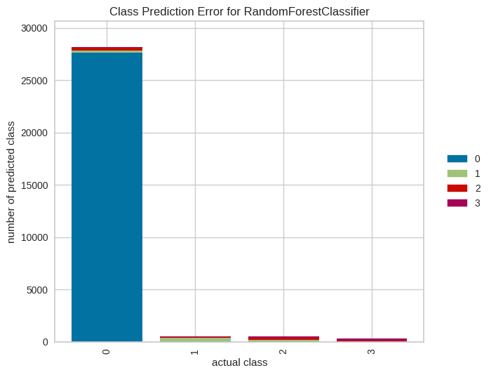

[figure not shown]

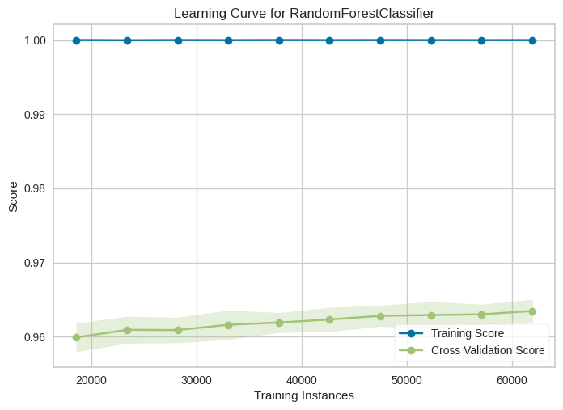

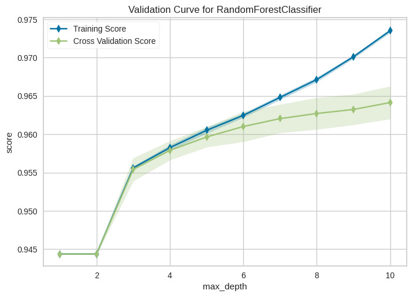

```python
graph_types = ['pipeline',
               'error',
               'feature_all',
               #'parameter',
               'learning',
               'vc',

]
for graph_type in graph_types:
    s.plot_model(best, plot= graph_type)
```

```python
s.predict_model(best)
```

|  | Model | Accuracy | AUC | Recall | Prec. | F1 | Kappa | MCC |
| --- | --- | --- | --- | --- | --- | --- | --- | --- |
| 0 | Random Forest Classifier | 0.9641 | 0.9763 | 0.9641 | 0.9598 | 0.9617 | 0.6329 | 0.6362 |

|  | obj_type | info | locality | population | income | total_sales | second_sales | water_access | elec_cons | building_perm | ... | lag_nearest_earthquake_distance | std_nearest_earthquake_distance | std_lag_nearest_earthquake_distance | lag_nearest_fault_distance | std_nearest_fault_distance | std_lag_nearest_fault_distance | lag_damage_gra | damage_gra | prediction_label | prediction_score |
| --- | --- | --- | --- | --- | --- | --- | --- | --- | --- | --- | --- | --- | --- | --- | --- | --- | --- | --- | --- | --- | --- |
| 88133 | 11_RESIDENTIAL_BUILDINGS | 997_NOT_APPLICABLE | SANLIURFA | 2170110 | 3012 | 177626 | 99010 | 0.95 | 1631 | 978 | ... | 1.752949 | 2.000054 | 1.999903 | 0.259521 | 0.893233 | 0.893697 | 1.0 | 0 | 1 | 1.0 |
| 56026 | 211_HIGHWAYS__STREETS_AND_ROADS | 21122_LOCAL_ROAD | ISLAHIYE | 67650 | 7819 | 4498 | 1892 | 1.00 | 4076 | 2959 | ... | 0.384963 | -0.550715 | -0.551145 | 0.016558 | -1.714454 | -1.712741 | 1.0 | 0 | 1 | 1.0 |
| 25394 | 11_RESIDENTIAL_BUILDINGS | 997_NOT_APPLICABLE | DUZICI | 85448 | 6256 | 6203 | 2289 | 0.95 | 7413 | 583 | ... | 0.472464 | -0.387397 | -0.387972 | 0.153133 | -0.250738 | -0.247603 | 1.0 | 0 | 1 | 1.0 |
| 5665 | 211_HIGHWAYS__STREETS_AND_ROADS | 21122_LOCAL_ROAD | ADIYAMAN | 316140 | 4092 | 40087 | 20574 | 0.98 | 2060 | 810 | ... | 1.105220 | 0.792037 | 0.792005 | 0.020621 | -1.668923 | -1.669153 | 1.0 | 0 | 1 | 1.0 |
| 31441 | 995_UNCLASSIFIED | 997_NOT_APPLICABLE | GAZIANTEP | 2154051 | 7819 | 248121 | 141434 | 1.00 | 4076 | 2959 | ... | 0.372488 | -0.574179 | -0.574408 | 0.267938 | 0.985212 | 0.983989 | 1.0 | 0 | 1 | 1.0 |
| ... | ... | ... | ... | ... | ... | ... | ... | ... | ... | ... | ... | ... | ... | ... | ... | ... | ... | ... | ... | ... | ... |
| 91311 | 11_RESIDENTIAL_BUILDINGS | 997_NOT_APPLICABLE | SANLIURFA | 2170110 | 3012 | 177626 | 99010 | 0.95 | 1631 | 978 | ... | 1.778981 | 2.047543 | 2.048449 | 0.264129 | 0.939282 | 0.943130 | 1.0 | 0 | 1 | 1.0 |
| 38864 | 995_UNCLASSIFIED | 997_NOT_APPLICABLE | GAZIANTEP | 2154051 | 7819 | 248121 | 141434 | 1.00 | 4076 | 2959 | ... | 0.379147 | -0.562340 | -0.561992 | 0.249292 | 0.783171 | 0.783967 | 1.0 | 0 | 1 | 1.0 |
| 21046 | 11_RESIDENTIAL_BUILDINGS | 997_NOT_APPLICABLE | DUZICI | 85448 | 6256 | 6203 | 2289 | 0.95 | 7413 | 583 | ... | 0.449278 | -0.431394 | -0.431209 | 0.132131 | -0.473651 | -0.472910 | 1.0 | 2 | 1 | 1.0 |
| 95538 | 211_HIGHWAYS__STREETS_AND_ROADS | 21122_LOCAL_ROAD | SANLIURFA | 2170110 | 3012 | 177626 | 99010 | 0.95 | 1631 | 978 | ... | 1.774409 | 2.039933 | 2.039923 | 0.291820 | 1.240028 | 1.240191 | 1.0 | 0 | 1 | 1.0 |
| 18219 | 11_RESIDENTIAL_BUILDINGS | 997_NOT_APPLICABLE | BAHCE | 22904 | 6256 | 1588 | 664 | 0.95 | 7413 | 583 | ... | 0.352102 | -0.612285 | -0.612426 | 0.094220 | -0.880049 | -0.879603 | 1.0 | 0 | 1 | 1.0 |

29482 rows × 51 columns

## 6. Interpretation of the model

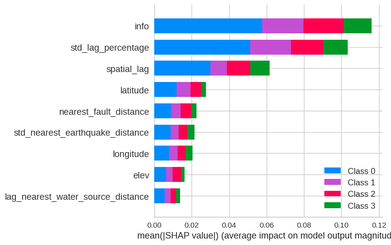

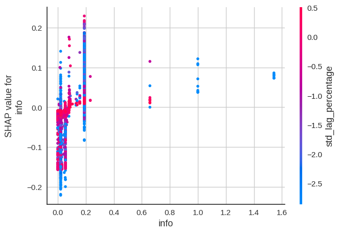

```python
interpretation_plots = ['summary',
                        'correlation',
                        'reason',
                        'pdp',
                        'msa',
                        'pfi'
                        ]


for plot in interpretation_plots:
    s.interpret_model(best, plot = plot)
```

[output not shown]

```python
s.save_model(best, '../data/models/my_best_classification.pkl')
```